# Table of Contents (Jupyter)

# 6. Actionable Insights & Recommendations

## 6.4 Insights from Model Results

> **Alternative Approaches Considered:** Beyond our chosen aggregated approach, other options included:
> - (1) multi-sample tuning—validating parameters across multiple random pages for robustness;
> - (2) global ML models—training a single LightGBM/XGBoost model on features from all series;
> - (3) clustering—grouping similar pages and modeling each cluster separately; and
> - (4) deep learning methods like DeepAR or N-BEATS designed for large-scale multi-series forecasting. The aggregated approach was selected for its simplicity and alignment with segment-level forecasting objectives.

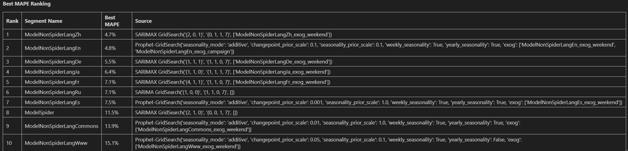

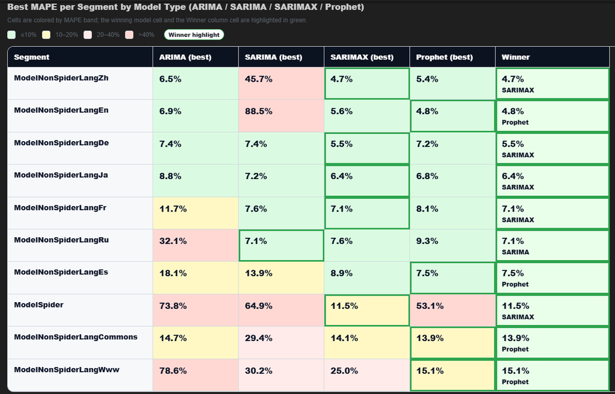

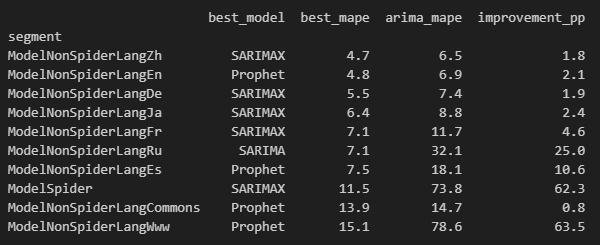

## 6.6 Questionnaire:

**1. Defining the problem statements and where can this and modifications of this be used?**

- The the goal of the case study is to predict the page view per segment (segment could be language or language + some more criteria, which will be determined during the course of the study)
- Final aim of user is to answer this question
  - **If I place my ad on French pages, how many page views can I expect**,
  - **If I place my ad on English pages, how many page views can I expect**

**2. Write 3 inferences you made from the data visualizations**

**3. What does the decomposition of series do?**

- Decompose the time series into trend, seasonality and residuals component series. Each of the component series can then be plotted and analyzed.

**4. What level of differencing gave you a stationary series?**

- One

**5. Difference between arima, sarima & sarimax.**

- SARIMAX offers ARIMA + Seasonal components(P,D,Q,s) and Exogeneous varlables.
- SARIMA does not offer Exogeneous varlables.
- ARIMA does not offer seasonal components or exogeneous regressors.

**6. Compare the number of views in different languages**

- commons 10477
- de 18438
- en 24010
- es 14041
- fr 17761
- ja 20340
- ru 14990
- www 7251
- zh 17103

**7. What other methods other than grid search would be suitable to get the model for all languages?**

- pmdarima.arima.auto_arima